# Hector Medeiros - Lab 1 CDD UFCG 2019.1

```r
atividade = read_projectdata()


validos = atividade %>%
          filter(!is.na(twitter),
                 !is.na(segue),
                 !is.na(seguidores))
```

O dataset utilizado será o válidos que exclui os parlamentares que não possuem Twitter, ou possuem conta mas nunca a utilizara, ou seja não possuem seguidores e nem seguem alguém. Foram excluídos 59 parlamentares que não possuem conta no Twitter, e o número dos que não faz uso da conta foi 179, resultando num total de 238 exclusões.

#Quais os congressistas com um engajamento proporcional ao seu número de seguidores ? Existem parlamentares que possuem muitos seguidores e existem aqueles que possuem um engajamento total elevado. Será que é possível perceber algum tipo de correlação entre esses tópicos ?

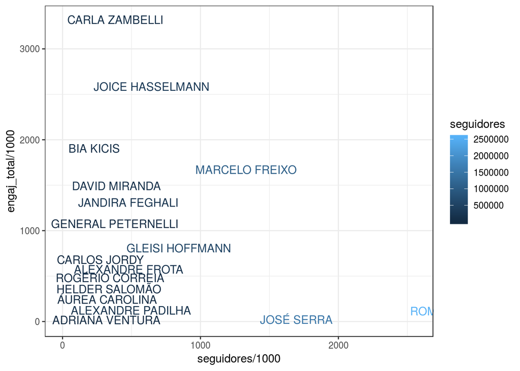

```r
validos %>%
  ggplot(title="Número",aes(x = seguidores/1000, y =engaj_total/1000, colour=seguidores)) +
  geom_text(check_overlap = TRUE,aes(label =ifelse(seguidores>1000,as.character(nome_eleitoral),''))
            ,hjust=.1,vjust=0.4)
```

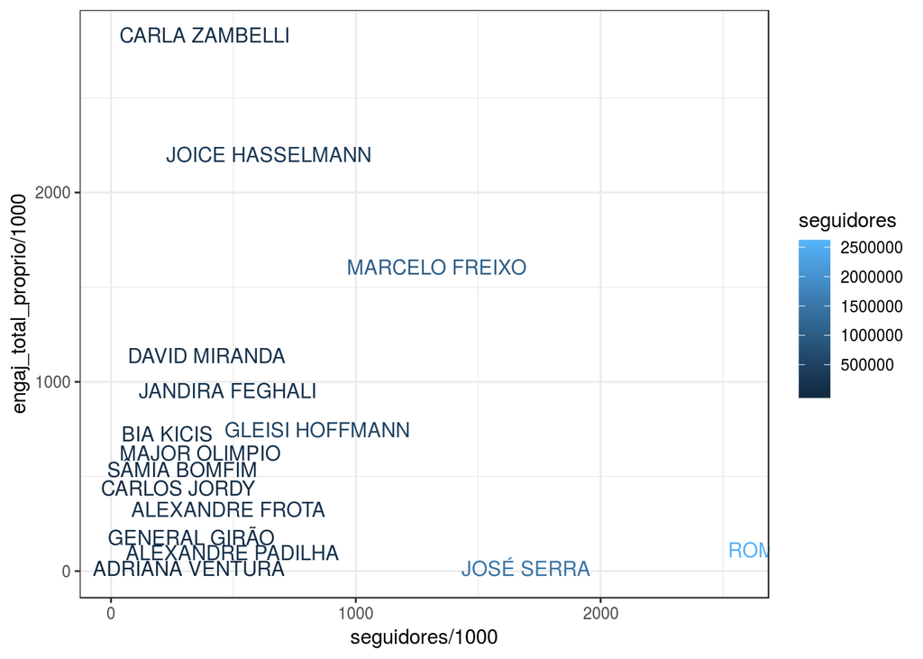

```r
validos %>%
  ggplot(aes(x = seguidores/1000, y =engaj_total_proprio/1000, colour=seguidores)) +
    geom_text(check_overlap = TRUE,aes(label =ifelse(seguidores>1000,as.character(nome_eleitoral),''))
              ,hjust=.1,vjust=0.4)
```

Se levarmos em consideração o engajamento total próprio o panaroma geral não sofre grande alteração. A deputada Carla Zambelli continua no topo, mas se levaramos em consideração o engajamento mediano percebe-se que a deputada não configura no gráfico, utilzar a mediana é uma boa medida para avaliar as distribuições pois ela ignora os valores extremos que é o caso da deputada Zambelli.

#Qual o deputado com mais seguidores com maior enjamento mediano ? E engajamento mediano propŕio ?

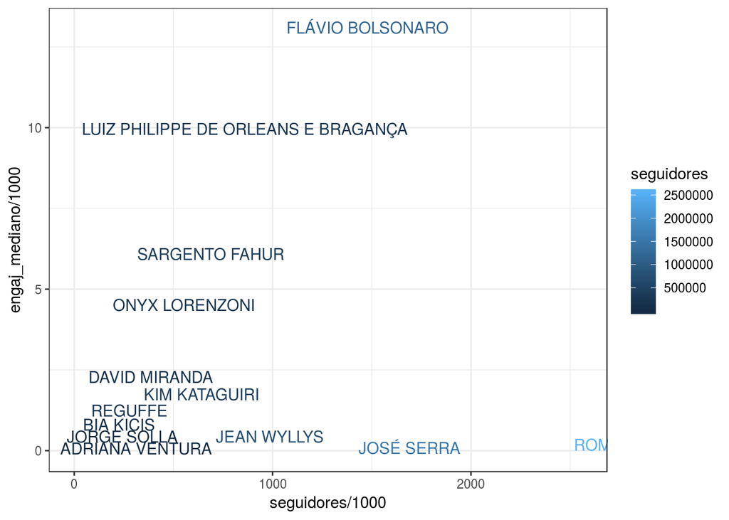

```r
validos %>%
  ggplot(aes(x = seguidores/1000, y =engaj_mediano/1000, colour=seguidores)) +
    geom_text(check_overlap = TRUE,aes(label =ifelse(seguidores>1000,as.character(nome_eleitoral),''))
              ,hjust=.1,vjust=0.4)
```

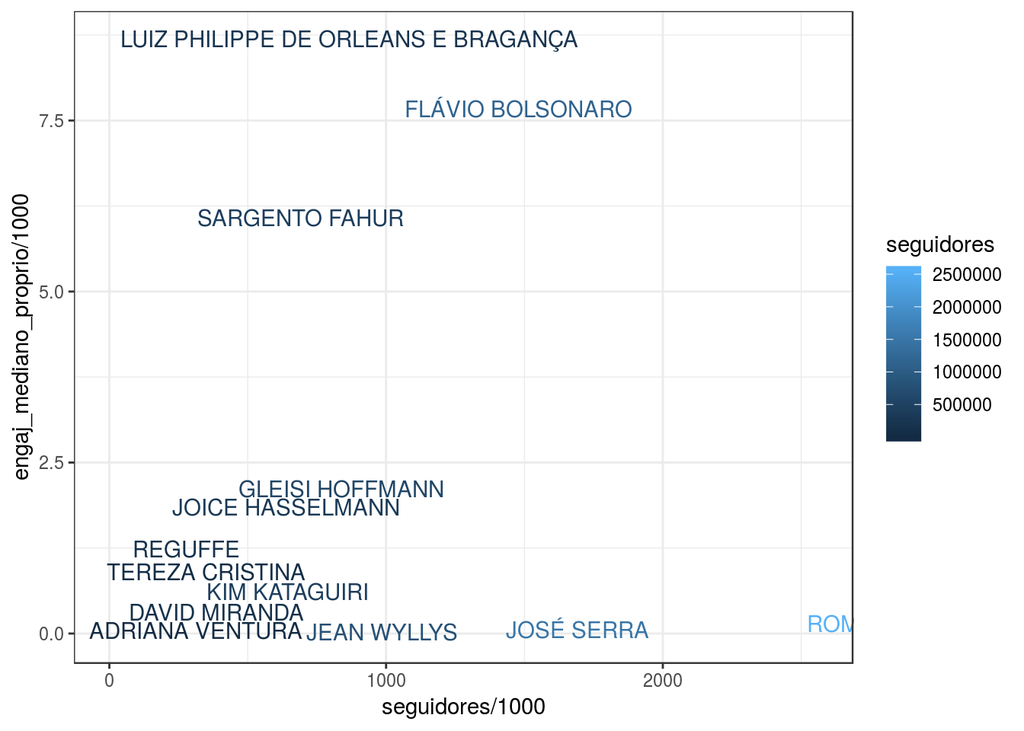

```r
validos %>%
  ggplot(aes(x = seguidores/1000, y =engaj_mediano_proprio/1000, colour=seguidores)) +
    geom_text(check_overlap = TRUE,aes(label =ifelse(seguidores>1000,as.character(nome_eleitoral),''))
              ,hjust=.1,vjust=0.4)
```

#A quais estados pertencem os congressistas com os maiores engajamentos nos seus tweets ?

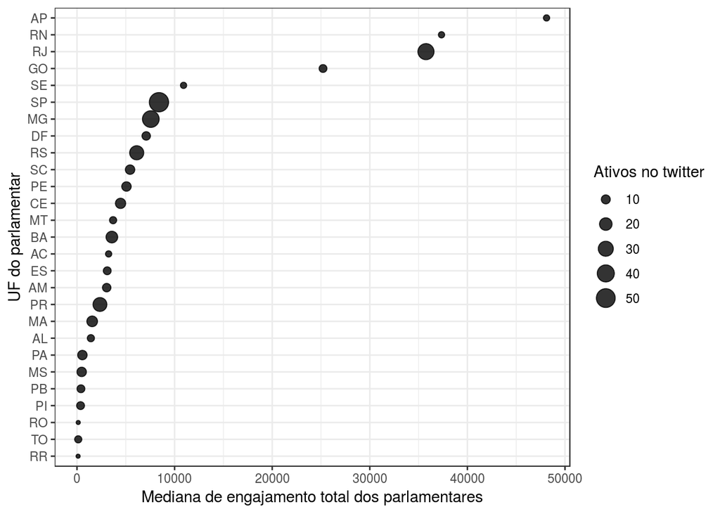

```r
validos %>%
  group_by(UF) %>%
  summarise(mediana_engajamento = median(engaj_total),
            parlamentares = n()) %>%
  ggplot(aes(
    x = reorder(UF, mediana_engajamento),
    y = mediana_engajamento,
    size = parlamentares
  )) +
  geom_point(alpha = .8) +
  coord_flip() +
  labs(x = "UF do parlamentar",
       y = "Mediana de engajamento total dos parlamentares",
       size = "Ativos no twitter")
```

Segundo o gráfico o estado que possui o maior engajamento mediano dos seus parlamentares é o Amapá. Já os estados que possuem um número elevado de congressistas no Twitter, o que possui o maior engajamento é o Rio de Janeiro.

#Por que o Amapá possui engajamento mediano tão elevado ? O estado do Amapá possui poucos parlamentares, 3 deputados e 3 senadores. Então por qual motivo esse estado possui em engajamento médio tão elevado ?

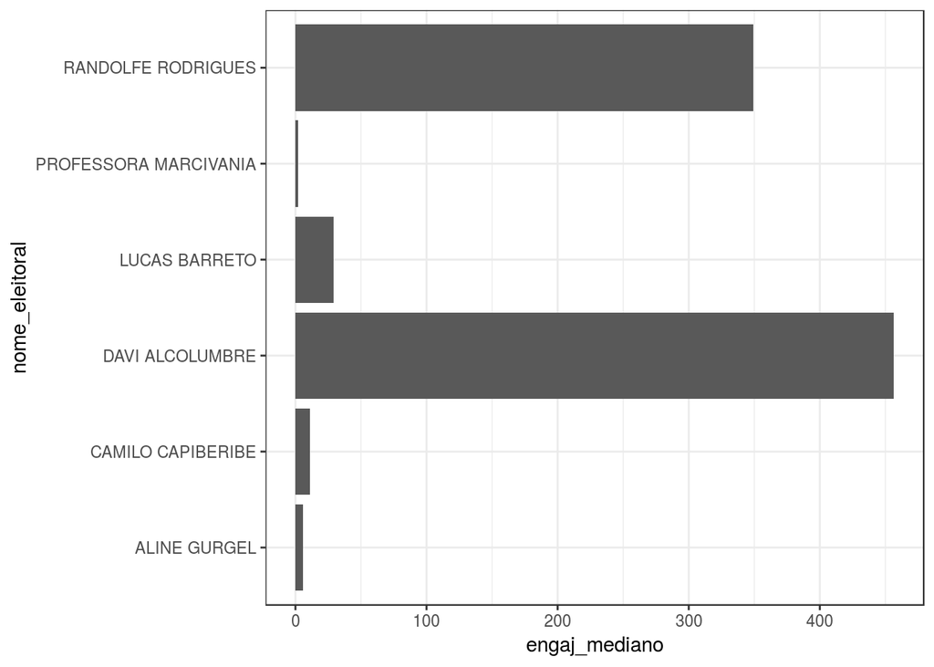

```r
validos %>%
  filter(!is.na(engaj_mediano), UF == "AP") %>%
  ggplot(aes(x = nome_eleitoral, y = engaj_mediano)) +
  geom_col() +
  coord_flip()
```